# Project Final Submission Template

### Step 1a: Planning

#### Identify the information in the file your program will read

Describe (all) the information that is available. Be sure to note any surprising or unusual features. (For example, some information sources have missing data, which may be blank or flagged using values like -99, NaN, or something else.)

In the csv file for "pokemon_stats.csv" we get all the pokemon data for 801 pokemons. The datas included are abilities (in str), multiplier weakness against all 18 types of pokemon (in float), base attack (in int), base egg steps (in int), base happiness (in int), base total (in int), classification (in str), defense (in int), experience growth (in int), height (in float), hp (in int), japanese name (in str), name (in str), percentage male (in float), pokedex number (in int), sp attack (in int), sp defense (in int), speed (in int), type 1 (in str), type 2 (in str), weight in kg (in float), generation (in int), is legendary (in int or bool). A pokemon might or might not have a second type (type 2) in which case the column for type 2 if there is no type 2 might be represented as (''), an empty string hence we will deal with an optional.

### Step 1b: Planning

#### Brainstorm ideas for what your program will produce

#### Select the idea you will build on for subsequent steps

You must brainstorm at least three ideas for graphs or charts that your program could produce and choose the one that you'd like to work on. You can choose between a line chart, histogram, bar chart, scatterplot, or pie chart.

If you would like to change your project idea from what was described in the proposal, you will need to get permission from your project TA. This is intended to help ensure that your new project idea will meet the requirements of the project. Please see the project proposal for things to be aware of when communicating with your project TA.

As my program would produce the strongest Pokemon for Type 1 as fire and a second type pokemon by calculating a modified defence value by using the against other types values for the pokemon, and modifying the defense value,so it can produce a bar chart, scatter plot or a pie chart.

For my project, the program is going to take in the pokemon stats csv file and the fire type pokemons, filter out all the fire type pokemons which have a second type, calculate the modified defense value and output the a bar chart where the name of the pokemon would be on the x-axis and the modified defense on the y-axis

### Step 1c: Planning

#### Write or draw examples of what your program will produce

You must include an image that shows what your chart or plot will look like. You can insert an image using the Insert Image command near the bottom of the Edit menu.

expect(main("pokemon_stats.csv"), None).

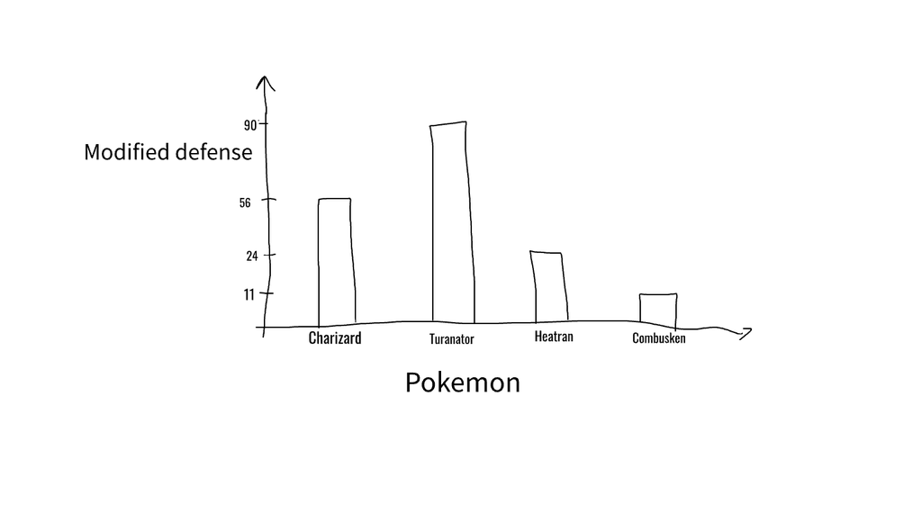

### Step 2a: Building

#### Document which information you will represent in your data definitions

Before you design data definitions in the code cell below, you must explicitly document here which information in the file you chose to represent and why that information is crucial to the chart or graph that you'll produce when you complete step 2c.

For this program we are going to take are going to be dealing with the Type 1, Type 2, "against_type" values, the defense values and names for each fire type pokemon that has a second type. The defense values and "against_type" values are going to be crucial for calculating the modified defense value. Type 1 for filtering the information to be used and name to be output. In the bar chart, the Pokemon Name would be in the X-axis value and the modified defense would be the Y-axis values.

#### Design data definitions

```python
from cs103 import *
from typing import NamedTuple, List, Optional
import csv
import matplotlib.pyplot as pyplot

##################
# Data Definitions
Type2Checker = Optional[str]

#interp. there is no Type 2 for a pokemon (none), or there is a Type 2 of str

T2C_0 = None
T2C_1 = "poison"
T2C_2 = "fire"
T2C_3 = "flying"

@typecheck
#Template based on optional
def fn_for_type_2_checker(t: Type2Checker) -> ...:
    if t == None:
        return ...
    else:
        return ...(t)





PokemonStats = NamedTuple("PokemonStats", [("against_bug", float),
                                           ("against_dark", float),
                                           ("against_dragon", float),
                                           ("against_electric", float),
                                           ("against_fairy", float),
                                           ("against_fight", float),
                                           ("against_fire", float),
                                           ("against_flying", float),
                                           ("against_ghost", float),
                                           ("against_grass", float),
                                           ("against_ground", float),
                                           ("against_ice", float),
                                           ("against_normal", float),
                                           ("against_poison", float),
                                           ("against_psychic", float),
                                           ("against_rock", float),
                                           ("against_steel", float),
                                           ("against_water", float),
                                           ("defense", int),
                                           ("name", str),
                                           ("type1", str),
                                           ("type2", Type2Checker)])

#interpr. PokemonStats including all the values against each of the 18 types of pokemon in float,
#the defense value in int, name in str, the Type1 in str
#and the Type 2 in the built in data type Type2Checker which is used to check if there is a type 2
#or not.


PS1 = PokemonStats(2.0,1.0,1.0,0.5,0.5,1.0,1.0,0.5,2.0,2.0, 1.0, 1.0, 0.5, 0.5, 2.0, 1.0, 2.0, 0.5, 78, "Charmander", "fire", "ghost")
PS2 = PokemonStats(1,2,1,1,0.5,1,2,0.5,2,0.5, 1, 1, 0.5, 1, 0.5, 1, 2, 0.5, 78, "Pidgey", "flying", None)
PS3 = PokemonStats(1.0,1.0,1.0,0.5,0.5,0.5,2.0,2.0,1.0,0.25,1.0,2.0,1.0,1.0,2.0,1.0,1.0,0.5, 49, "Bulbasaur", "grass", "poison")
PS4 = PokemonStats(0.5,1.0,1.0,1.0,0.5,1.0,0.5,1.0,1.0,0.5,2.0,0.5,1.0,1.0,1.0,2.0,0.5,2.0, 58, "Charmeleon","fire", None)
PS5 = PokemonStats(0.5,1.0,1.0,1.0,0.5,1.0,0.5,1.0,1.0,0.5,2.0,0.5,1.0,1.0,1.0,2.0,0.5,2.0, 58, "Rivoflavin","fire", "flying")
PS6 = PokemonStats(0.5,1.0,1.0,1.0,0.5,1.0,0.5,1.0,1.0,0.5,2.0,0.5,1.0,1.0,1.0,2.0,0.5,2.0, 58, "Charmeleon","fire", "poison")



@typecheck
#Template based on Compounds and reference rule
def fn_for_pokemon_stats(ps: PokemonStats) -> ...:
    return ...(ps.against_bug,
               ps.against_dark,
               ps.against_dragon,
               ps.against_electric,
               ps.against_fairy,
               ps.against_fight,
               ps.against_fire,
               ps.against_flying,
               ps.against_ghost,
               ps.against_grass,
               ps.against_ground,
               ps.against_ice,
               ps.against_normal,
               ps.against_poison,
               ps.against_psychic,
               ps.against_rock,
               ps.against_steel,
               ps.against_water,
               ps.defense,
               ps.name,
               ps.type1,
               fn_for_type_2_checker(ps.type2))




# List[PokemonStats]
# interp. a list of PokemonStats

LOPS0 = []
LOPS1 = [PS3, PS4]

@typecheck
def fn_for_lops(loc: List[PokemonStats]) -> ...: #Template based on arbitrary-sized
    # description of the accumulator
    acc = ...      # type: ...
    for s in lops:
        acc = ...(s, acc)

    return ...(acc)
```

### Step 2b and 2c: Building

#### Design a function to read the information and store it as data in your program

#### Design functions to analyze the data

Complete these steps in the code cell below. You will likely want to rename the analyze function so that the function name describes what your analysis function does.

Unless approved by your project TA, you **cannot** use libraries such as `numpy` or `pandas`. The project is meant as a way for you to demonstrate your knowledge of the learning goals in this course. While it is convinent to use external libraries, it will do all the work and will not help us gauge your mastery of the concepts.

You also cannot use built in list functions (e.g., `sum` or `average`) when writing code to do your substantial computation. Normally we encourage you to make use of what is already available but in this case, the final project involves demonstrating skills from class (e.g., how to work with a list). Using pre-built functions for this does not enable you to demonstrate what you know.

If you wish to change your project idea, you must **first** obtain permission from your TA. When contacting your TA, please provide a valid reason for why you want to change your project. Each time you change your topic idea, your TA will have to evaluate it to see if it will meet all of the project requirements. This is non-trivial task during one of the busiest times of the semester. As such, the deadline for project idea changes will be 3 business days before the deadline. Note that the deliverable deadline will not be extended and there is no compensation for the time you spent on the previous idea.

```python
#Helper Functions
@typecheck
def parse_type(t: Type2Checker) -> Optional[str]:
    """
    returns None if there is no type 2 or the type in strings if there is
    a second type
    """
    #return "" #stub

    #Template
    if t == "":
        return None
    else:
        return t

start_testing()

expect(parse_type("ghost"), "ghost")
expect(parse_type(""), None)
expect(parse_type("flying"), "flying")

summary()
```

```
3 of 3 tests passed
```

```python
#Helper Functions
@typecheck
def type_2_exists(t: Type2Checker) -> bool:
    """
    returns True if a second type of the pokemon exist
    """

    #return True #stub

    if t == None:
        return False
    else:
        return True


start_testing()

expect(type_2_exists(T2C_0), False)
expect(type_2_exists(T2C_1), True)
expect(type_2_exists(T2C_2), True)

summary()
```

```
3 of 3 tests passed
```

```python
#Helper Functions
@typecheck
def modified_defense(ps: PokemonStats) -> float:
    """
    returns the modified defense of the pokemon
    """

    #return 0.0 #stub

    all_against_multiplier = ps.against_bug+ps.against_dark+ps.against_dragon+ps.against_electric+ps.against_fairy+ps.against_fight+ps.against_fire+ps.against_flying+ps.against_ghost+ps.against_grass+ps.against_ice+ps.against_normal+ps.against_poison+ps.against_psychic+ps.against_rock+ps.against_steel+ps.against_water
    mod_def = ps.defense/all_against_multiplier
    return mod_def

start_testing()

expect(modified_defense(PS1), 4.105263)

summary()
```

```
1 of 1 tests passed
```

[figure not shown]

[figure not shown]

[figure not shown]

[figure not shown]

```
6 of 6 tests passed
```

```python
# Functions

@typecheck
def main(filename: str) -> None:
    """
    Reads the file from given filename and creates a bar chart showing the modified defense of
    dual fire type pokemons
    """
    # Template from HtDAP, based on function composition
    return plot_bar_chart((read(filename)))



@typecheck
def read(filename: str) -> List[PokemonStats]:
    """
    reads information from the specified file and returns returns all the pokemon
    stats in a list
    """
    #return []  #stub
    # Template from HtDAP
    # lops contains the result so far
    lops = [] # type: List[PokemonStats]

    with open(filename) as csvfile:

        reader = csv.reader(csvfile)
        next(reader) # skip header line

        for row in reader:
            # you may not need to store all the rows, and you may need
            # to convert some of the strings to other types
            ps = PokemonStats(parse_float(row[1]),
                              parse_float(row[2]),
                              parse_float(row[3]),
                              parse_float(row[4]),
                              parse_float(row[5]),
                              parse_float(row[6]),
                              parse_float(row[7]),
                              parse_float(row[8]),
                              parse_float(row[9]),
                              parse_float(row[10]),
                              parse_float(row[11]),
                              parse_float(row[12]),
                              parse_float(row[13]),
                              parse_float(row[14]),
                              parse_float(row[15]),
                              parse_float(row[16]),
                              parse_float(row[17]),
                              parse_float(row[18]),
                              parse_int(row[25]),
                              row[30],
                              row[36],
                              parse_type(row[37]))

            lops.append(ps)

    return lops


@typecheck
def plot_bar_chart(lops: List[PokemonStats]) -> None:
    """
    creates a bar chart showing the modified defense of dual fire type pokemons
    and returns None
    """

    #return None #stub
    # Template based on Visualisation

    #list of pokemon names
    pokemon = []

    #list of modified defense
    modified_def = []

    for ps in lops:
        if type_2_exists(ps.type2) and ps.type1 == "fire":
            pokemon.append(ps.name)
            mod_def = modified_defense(ps)
            modified_def.append(mod_def)

    fig, ax = pyplot.subplots(1,1)
    ax.bar(pokemon, modified_def, color = "orange", width = 0.8)
    ax.set_xlim(-1, len(pokemon))


    pyplot.xticks(pokemon, rotation = 'vertical')

    pyplot.xlabel("Pokemon")
    pyplot.ylabel("Modified Defense")
    pyplot.title("Dual Fire Type Pokemon Defense")


    #show the plot
    pyplot.show()

    return None





start_testing()

# Examples and tests for main
expect(main("pokemonstat5.csv"), None)
expect(main("pokemonstat4.csv"), None)



#Examples for plot_bar_chart
expect(plot_bar_chart([PS1, PS4, PS5]), None)
expect(plot_bar_chart([PS1, PS2]), None)





#Examples and tests for read
expect(read("pokemonstat1.csv"), [PS3])
expect(read("pokemonstat2.csv"), LOPS1)


summary()
```

### Final Graph/Chart

Now that everything is working, you **must** call `main` on the intended information source in order to display the final graph/chart:

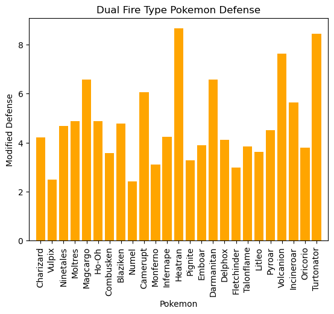

```python
main("pokemon_stats.csv")
```

```python
# Be sure to select ALL THE FILES YOU NEED (including csv's)
# when you submit. As usual, you cannot edit this cell.
# Instead, run this cell to start the submission process.
from cs103 import submit

COURSE = 123409
ASSIGNMENT = 1615244 # Final submission

submit(COURSE, ASSIGNMENT)

# If your submission fails, SUBMIT by downloading your files and uploading them
# to Canvas. You can learn how on the page "How to submit your Jupyter notebook"
# on our Canvas site.
```

# Please double check your submission on Canvas to ensure that the right files (Jupyter file + CSVs) have been submitted and that the files do not contain unexpected errors.

**You should always check your submission on Canvas. It is your responsibility to ensure that the correct file has been submitted for grading.** Regrade or accomodation requests using reasoning such as "I didn't realize I submitted the wrong file"/"I didn't realize the submission didn't work"/"I didn't realize I didn't save before submitting so some of my work is missing" will not be considered.